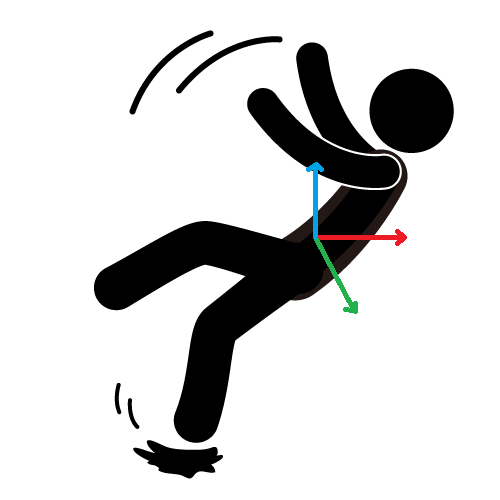

# **Fall detection with direction and severity**

I have worked on the development of machine and deep learning methods for determining falls from inertial measurement sensor unit data while considering direction and severity. **Time series** signals from accelerometer and gyroscope sensors were used from the [SisFall dataset](https://www.ncbi.nlm.nih.gov/pmc/articles/PMC5298771/). The problem was looked at both in a fall only scenario and an activity of daily living plus fall detection scenario with experimentation conducted for different cases. The methodologies developed used signal processing techniques such as *filtering, resampling, augmentation, wavelets* and *time* and *frequency* domain computations. Several machine and deep learning learning methods were used including *Support Vector Machines, Decision Trees, Random Forests, Grandient Boosted Trees, Convolutional Neural Networks* and *Long Short Term Memory Networks* used for classification. The work carried out was published in conferences and journals.

[Determining Fall direction and severity using SVMs](https://ieeexplore.ieee.org/abstract/document/9408879)

[A Hierarchical Approach to Activity Recognition and Fall Detection Using Wavelets and Adaptive Pooling](https://www.mdpi.com/1424-8220/21/19/6653)

[A Deep Convolutional Neural Network-XGB for Direction and Severity Aware Fall Detection and Activity Recognition](https://www.mdpi.com/1424-8220/22/7/2547)

[Cross dataset non-binary fall detection using a ConvLSTM-attention network](https://ieeexplore.ieee.org/abstract/document/10008565/)

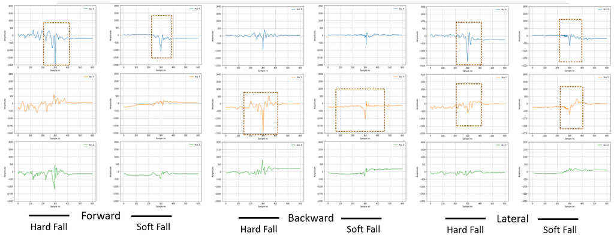